# Gene expression processing

Tom van Schaik

2021-09-16

### Project description

Gene expression profiling of HCT116 cells after Ki67 depletion.

### Introduction

Basic differential expression analysis with DESeq2.

### Method

DESeq2.

### Set-up

Load the libraries and set the parameters.

```r
# Load dependencies
library(tidyverse)
library(GenomicRanges)
library(rtracklayer)
library(ggplot2)
library(ggbeeswarm)
library(DESeq2)
library(RColorBrewer)
library(GGally)

# # Prepare output
output_dir <- "ts210514_rnaseq_processing"
dir.create(output_dir, showWarnings = FALSE)


# Centromere positioning
input_dir <- "../ts200921_LaminaNucleolus_AdditionalExperiments/ts210413_data_gathering"
centromeres <- readRDS(file.path(input_dir, "centromeres.rds"))
```

```r
library(knitr)
opts_chunk$set(fig.width = 10, fig.height = 4, cache = T,
               dev=c('png', 'pdf'), fig.path = file.path(output_dir, "figures/"))
pdf.options(useDingbats = FALSE)
```

```r
ExonLength <- function(genes) {
  # Get the combined exon length for the genes
  tib <- as_tibble(genes) %>%
    filter(type == "exon") %>%
    mutate(gene_id = factor(gene_id, levels = unique(gene_id))) %>%
    group_by(gene_id) %>%
    dplyr::summarise(exon_number = n(),
              exon_length = sum(width))

  tib
}

# From Fede:
# ggpairs custom functions
corColor <- function(data, mapping, color = I("black"), sizeRange = c(1, 3), ...) {

  x   <- eval_data_col(data, mapping$x)
  y   <- eval_data_col(data, mapping$y)
  r   <- cor(x, y)
  rt  <- format(r, digits = 3)
  tt  <- as.character(rt)
  cex <- max(sizeRange)

  # helper function to calculate a useable size
  percent_of_range <- function(percent, range) {
    percent * diff(range) + min(range, na.rm = TRUE)
  }

  # plot correlation coefficient
  p <- ggally_text(label = tt, mapping = aes(), xP = 0.5, yP = 0.5,
                   size = I(percent_of_range(cex * abs(r), sizeRange)), color = color, ...) +
    theme(panel.grid.minor=element_blank(),
          panel.grid.major=element_blank())

  corColors <- RColorBrewer::brewer.pal(n = 7, name = "RdYlBu")[2:6]

  if (r <= boundaries[1]) {
    corCol <- corColors[1]
  } else if (r <= boundaries[3]) {
    corCol <- corColors[2]
  } else if (r < boundaries[3]) {
    corCol <- corColors[3]
  } else if (r < boundaries[4]) {
    corCol <- corColors[4]
  } else {
    corCol <- corColors[5]
  }

  p <- p +
    theme(panel.background = element_rect(fill = corCol))

  return(p)
}

plotMAWithLabels <- function(results, main, alpha = 0.05) {

  # Plot MA plot with lamin genes highlighted
  df <- DESeq2::plotMA(results, ylim = c(-4, 4), main = main,
                       ylab = "log2 fold change", alpha = alpha, returnData = T)

  ggplot(df, aes(x = mean, y = lfc)) +
    geom_bin2d(data = df[df$isDE == F, ], bins = 100) +
    geom_point(data = df[df$isDE == T, ], aes(col = T),
               size = 1, show.legend = T) +
    geom_hline(yintercept = 0, col = "black", linetype = "dashed") +
    xlab("Mean expression (cpm)") +
    ylab("Expression difference (log2)") +
    scale_x_log10() +
    scale_color_manual(values = c("red"), name = "Significant") +
    scale_fill_gradient(low = "lightgrey", high = "black", name = "Count") +
    # coord_cartesian(ylim = c(-4, 4),
    #                 xlim = c(1, max(df$mean, na.rm = T))) +
    coord_cartesian(ylim = c(-4, 4)) +
    theme_bw() +
    theme(aspect.ratio = 1)

  #points(results[c("ENSG00000148773"), "baseMean"],
  #       results[c("ENSG00000148773"), "log2FoldChange"],
  #       col = c("red"), cex = 1.5, pch = 19)
  #legend("topright",
  #       legend = c(paste0("non-sign (n=", sum(results$padj >= alpha, na.rm = T), ")"),
  #                  paste0("sign (n=", sum(results$padj < alpha, na.rm = T), ")"),
  #                  "Ki67"),
  #       col = c("black", "blue", "red"), pch = 19)

}
```

### 1. Prepare data and DESeq2

Read data files and initialize the DESeq2 object.

```r
#######################################
## Prepare metadata

# Prepare metadata sheet
metadata <- read_tsv("ts210514_metadata_PE.tsv") %>%
  filter(grepl("Ki67", sample_name)) %>%
  dplyr::select(-fastq) %>%
  #mutate(sample_id_short = str_remove(sample_id, "_R1_001")) %>%
  separate(sample_name, c("cell", "clone", "condition", "replicate"), sep = "_", remove = F) %>%
  mutate(condition = factor(condition, levels = unique(condition)),
         replicate = factor(replicate, levels = unique(replicate)))
#######################################
## Prepare gene annotation

# Load genes
genes <- import("/home/t.v.schaik/mydata/data/gene_builds/GRCh38/gencode.v24.primary_assembly.annotation.gtf")

# Get gene lengths (total exon length)
gene_length <- ExonLength(genes)

# dplyr::select genes only
genes <- genes[genes$type == "gene"]

# Add seqinfo
# chrom_sizes <- read.table("/DATA/usr/t.v.schaik/data/genomes/GRCh38/hg38.chrom.sizes", sep = "\t")
# row.names(chrom_sizes) <- chrom_sizes[, 1]
# seqlengths(genes) <- chrom_sizes[seqlevels(genes), 2]



#######################################
## Prepare count matrix

# Read count matrix corresponding to the metadata
rnaseq_matrix <- read_tsv("results_pe/Star/count_table.tsv") %>%
  dplyr::select(1, contains("Ki67")) %>%
  rename_at(vars(names(.)), ~ c("ensembl_id", metadata$sample_name))
# Filter for strange chromosomes
idx_chromosome <- which(seqnames(genes) %in% c(paste0("chr", 1:22),
                                               "chrX"))

genes <- genes[idx_chromosome]
rnaseq_matrix <- rnaseq_matrix[idx_chromosome, ]

# Filter for protein coding genes (for now), and lincRNA (similar to 4DN analysis)
filter <- c("protein_coding", "lincRNA")
#filter <- c("protein_coding")
idx_filter <- which(genes$gene_type %in% filter)

genes <- genes[idx_filter]
rnaseq_matrix <- rnaseq_matrix[idx_filter, ]

# # Filter for genes with no counts
# tib_nocounts <- rnaseq_matrix %>%
#   mutate(ensembl_id = factor(ensembl_id, levels = ensembl_id)) %>%
#   gather(key, value, -ensembl_id) %>%
#   group_by(ensembl_id) %>%
#   dplyr::summarise(count = sum(value > 2) > 2)
# idx_nocounts <- which(tib_nocounts$count)
#
# genes <- genes[idx_nocounts]
# rnaseq_matrix <- rnaseq_matrix[idx_nocounts, ]
```

```r
# Add distance to centromere
genes$distance_to_centromere <- as_tibble(distanceToNearest(genes,
                                                            centromeres,
                                                            ignore.strand = T)) %>%
  mutate(distance = distance / 1e6) %>%
  pull(distance)
```

```r
#######################################
## Prepare count matrix

# Convert into data.frame with row.names for deseq2
rnaseq_counts <- rnaseq_matrix %>%
  dplyr::select(-ensembl_id)
rnaseq_counts <- data.frame(rnaseq_counts, row.names = rnaseq_matrix$ensembl_id)


#######################################
## Initialize deseq2

# Prepare metadata ready for deseq
metadata_df <- data.frame(metadata)
metadata_df[] <- lapply(metadata_df, function(x) gsub("-", "_", x))

# Initialize
rnaseq_dds <- DESeqDataSetFromMatrix(countData = rnaseq_counts,
                                     colData = metadata_df,
                                     design= ~ condition)
# Execute deseq2
rnaseq_dds <- DESeq(rnaseq_dds)
```

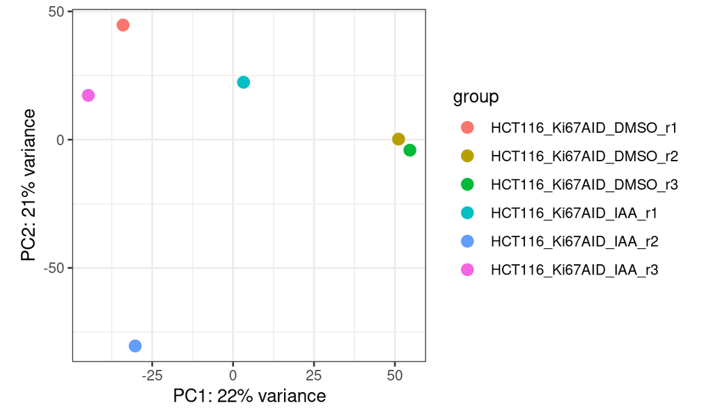

```r
#######################################
## PCA analysis - quality control

# Get the "normalized" values and create PCA plot
# Note that "normalized" is simply log2 + 0.01 transformed normalized counts!
rnaseq_dds_norm <- normTransform(rnaseq_dds, pc = 0.01)
plt <- plotPCA(rnaseq_dds_norm, intgroup = c("sample_name"))

plt +
  theme_bw() +
  theme(aspect.ratio = 1)
```

The PCA plot looks a bit weird. I guess this is because there are no differences between the conditions.

### 2. Correlation plot replicates

A quick initial test: how well do the replicates correlate with each other and between the different experiments?

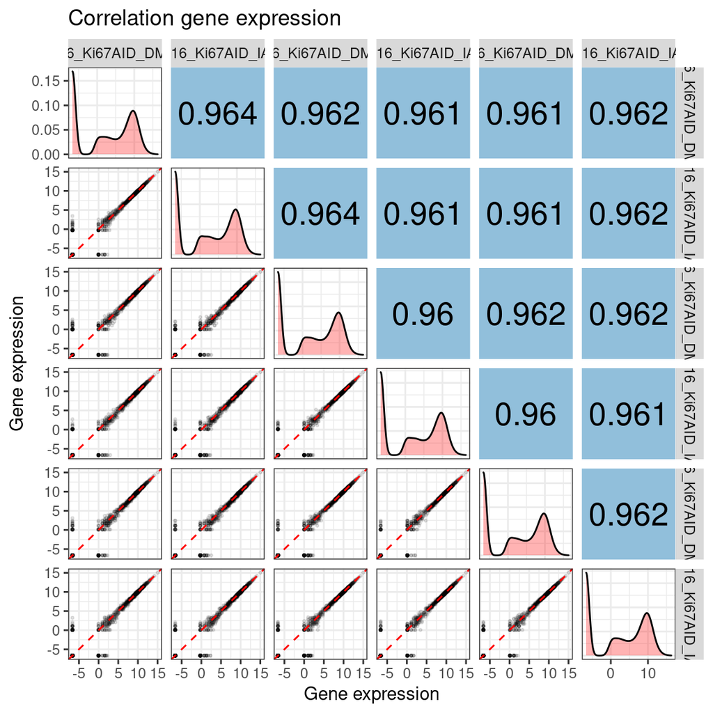

```r
#######################################
## Make a correlation plot of all samples - quality control

# Get the "normalized" counts for each experiment - this is a different
# normalized from above!
rnaseq_norm <- as_tibble(assay(rnaseq_dds_norm)) %>%
  rename_at(vars(names(.)), ~ metadata$sample_name) %>%
  add_column(ensembl_id = rnaseq_matrix$ensembl_id)

# rnaseq_norm <- rnaseq_norm[, order(samples.df$clone)]


# Also, combine the normalized counts
rnaseq_norm_combined <- do.call(cbind,
                                tapply(as.character(metadata$sample_name),
                                       metadata$condition,
                                       function(i) rowMeans(rnaseq_norm[, i])))

tib_norm_combined <- as_tibble(rnaseq_norm_combined,
                               .name_repair = ~c("DMSO", "IAA")) %>%
  add_column(gene_id = rnaseq_norm$ensembl_id)

tib_norm_combined <- as_tibble(genes) %>%
  dplyr::select(seqnames, start, end, strand, gene_id, gene_name) %>%
  inner_join(tib_norm_combined, by = "gene_id")


# Get a sample for plotting dplyr::select points
n <- sample(1:nrow(rnaseq_norm), 1000)

# Use GGally to make correlation plots
boundaries <- seq(from = 0.9, by = 0.01, length.out = 4)
plt <- ggpairs(rnaseq_norm %>% dplyr::select(-ensembl_id),
               upper = list(continuous = corColor),
               lower = list(continuous = function(data, mapping, ...) {
                   ggally_points(data = data[n, ], mapping = mapping, alpha = 0.1, size = 0.5) +
                   geom_abline(slope = 1, lty = "dashed", col = "red") +
                   theme_bw()}),
               diag = list(continuous = function(data, mapping, ...) {
                   ggally_densityDiag(data = data, mapping = mapping, alpha = 0.3, fill = "red") +
                   theme_bw()})) +
  ggtitle("Correlation gene expression") +
  xlab("Gene expression") +
  ylab("Gene expression")
  # theme_bw()

print(plt)
```

The main point of the figure: there is no single replicate misbehaving.

### 3. Differential analysis

I will perform differential tests:

- IAA vs DMSO

```r
#######################################
## Differential analysis - test for lfc > 0.5

# Differential analysis
diff_results <- results(rnaseq_dds, lfcThreshold = 0, alpha = 0.05,
                       contrast = c("condition", "IAA", "DMSO"))
summary(diff_results)
```

```
##
## out of 20109 with nonzero total read count
## adjusted p-value < 0.05
## LFC > 0 (up)       : 3, 0.015%
## LFC < 0 (down)     : 0, 0%
## outliers [1]       : 0, 0%
## low counts [2]     : 0, 0%
## (mean count < 0)
## [1] see 'cooksCutoff' argument of ?results
## [2] see 'independentFiltering' argument of ?results
```

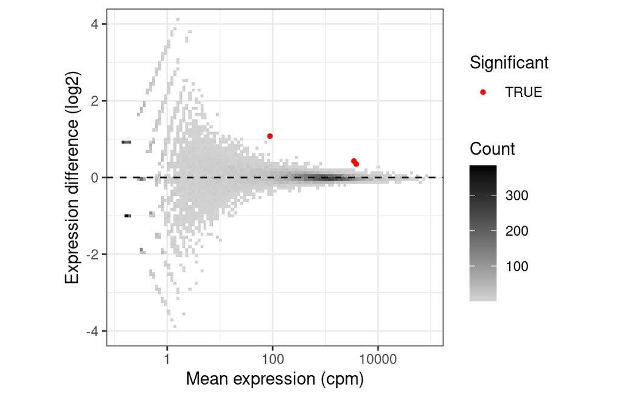

```r
# MA plots with significant hits
plotMAWithLabels(diff_results, main = "")
```

```r
# Print differential genes
as_tibble(diff_results) %>%
  add_column(gene_id = row.names(diff_results)) %>%
  filter(padj < 0.05) %>%
  left_join(as_tibble(genes)) %>%
  dplyr::select(gene_name, gene_id, baseMean, log2FoldChange, pvalue, padj,
                seqnames, start, end)
```

```
## # A tibble: 3 x 9
##   gene_name gene_id    baseMean log2FoldChange   pvalue     padj seqnames  start
##   <chr>     <chr>         <dbl>          <dbl>    <dbl>    <dbl> <fct>     <int>
## 1 CYP1A1    ENSG00000…     88.9          1.08  4.56e- 6  3.06e-2 chr15    7.47e7
## 2 ALDH1A3   ENSG00000…   3480.           0.427 1.05e-10  2.11e-6 chr15    1.01e8
## 3 HAS3      ENSG00000…   3855.           0.351 3.11e- 7  3.13e-3 chr16    6.91e7
## # … with 1 more variable: end <int>
```

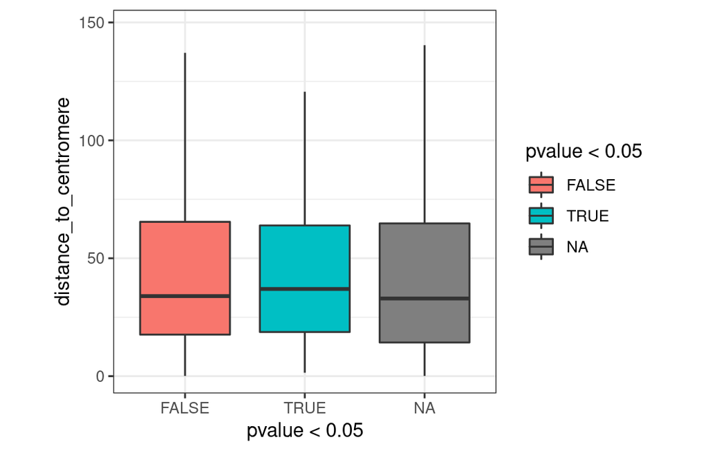

```r
# Quick question - are "mildly different changes" enriched near centromeres?
as_tibble(diff_results) %>%
  add_column(gene_id = row.names(diff_results)) %>%
  left_join(as_tibble(genes)) %>%
  dplyr::select(gene_name, gene_id, baseMean, log2FoldChange, pvalue, padj,
                seqnames, start, end, distance_to_centromere) %>%
  ggplot(aes(x = pvalue < 0.05, y = distance_to_centromere, fill = pvalue < 0.05)) +
  geom_boxplot(outlier.shape = NA) +
  theme_bw() +
  theme(aspect.ratio = 1)
```

### 4. Overlap with LADs

Finally, let’s ask the important question: are the differentially regulated genes found within LADs? This would suggest that LAD disruption has an effect on gene expression.

```r
#######################################
## Load LADs

# LADs: LAD definition in "wt" cells (clone 17)
LADs <- import("/home/t.v.schaik/mydata/proj/3D_nucleus/results/ts200921_LaminaNucleolus_AdditionalExperiments/results/HMM/bin-50kb/HCT116_AID_ctrl_LMNB1-50kb-combined_AD.bed.gz")

NADs <- import("/home/t.v.schaik/mydata/proj/3D_nucleus/results/ts200921_LaminaNucleolus_AdditionalExperiments/results/HMM/bin-50kb/HCT116_AID_ctrl_Ki67-50kb-combined_AD.bed.gz")


#######################################
## Determine overlap genes with LADs/NADs

genes$overlaps_LAD <- overlapsAny(genes, LADs, type = "any")
genes$overlaps_NAD <- overlapsAny(genes, NADs, type = "any")
```

Plot the enrichment of differential genes within LADs.

```r
#######################################
## Create summarizing tibble - only using active genes

tib <- as_tibble(diff_results) %>%
  dplyr::select(baseMean, log2FoldChange, padj) %>%
  add_column(ensembl_id = genes$gene_id,
             overlaps_LAD = genes$overlaps_LAD,
             overlaps_NAD = genes$overlaps_NAD) %>%
  mutate(padj = replace_na(padj, 1))

tib_gather <- tib %>%
  dplyr::select(-starts_with("log")) %>%
  gather(key, value, contains("overlaps")) %>%
  mutate(sign = padj < 0.05)

# Group by LAD overlap or significance
tib_diff <- tib_gather %>%
  group_by(key, value) %>%
  dplyr::summarise(fraction = mean(sign),
            total = sum(sign),
            background = length(sign))
```

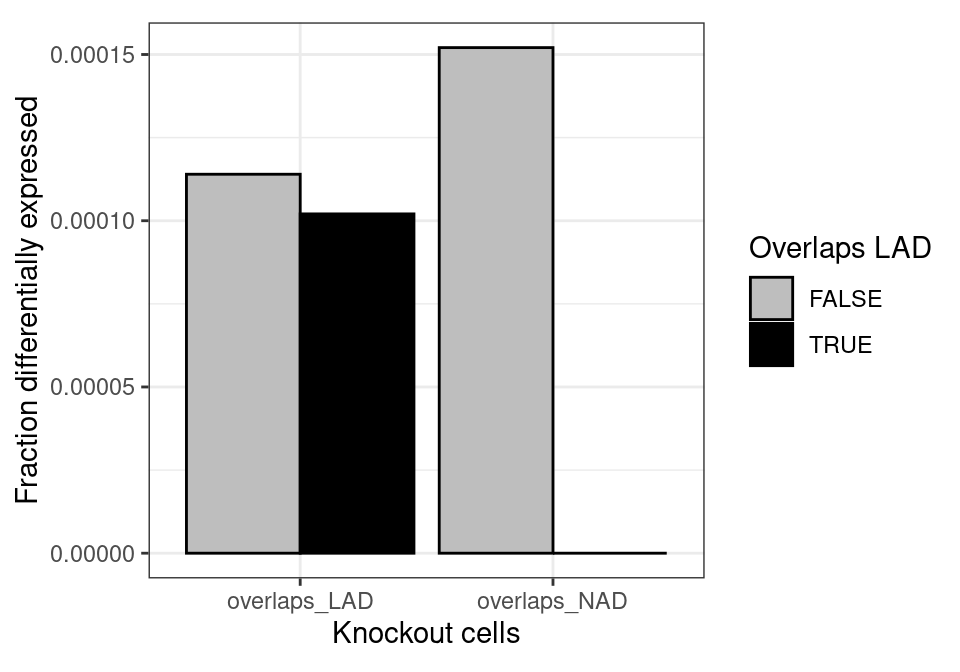

```r
#######################################
## Plot results

tib_diff %>%
  ggplot(aes(x = key, y = fraction, fill = value)) +
    geom_bar(stat = "identity", position = "dodge", col = "black") +
    xlab("Knockout cells") +
    ylab("Fraction differentially expressed") +
    scale_fill_manual(values = c("grey", "black"), name = "Overlaps LAD") +
    theme_bw() +
    theme(aspect.ratio = 1)
```

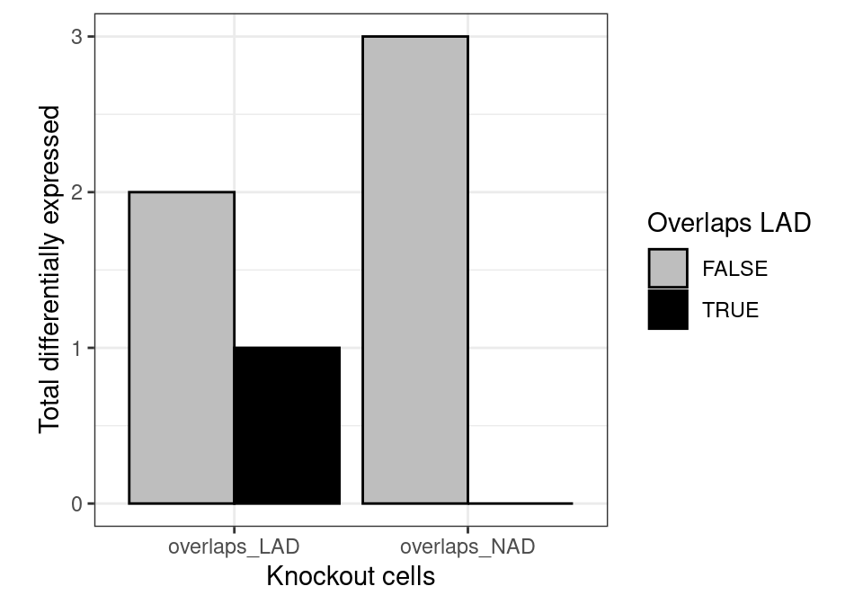

```r
tib_diff %>%
  ggplot(aes(x = key, y = total, fill = value)) +
    geom_bar(stat = "identity", position = "dodge", col = "black") +
    xlab("Knockout cells") +
    ylab("Total differentially expressed") +
    scale_fill_manual(values = c("grey", "black"), name = "Overlaps LAD") +
    theme_bw() +
    theme(aspect.ratio = 1)
```

Not significant.

The analysis above is based on differential gene expression and simply asking whether LAD genes are over-represented. However, there is a bias in gene expression levels in LAD genes compared to iLAD genes: they often are more lowly expressed. It could that this bias also affects the result. To rule this out, let’s create a matched set (Christ’s script) and use that.

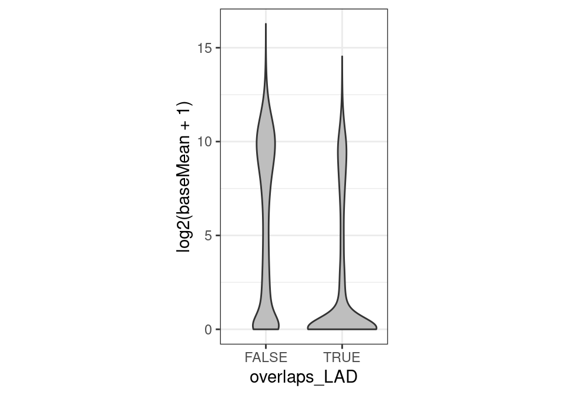

```r
## Function by Christ Leemans
## Create a matched set
##
## get a table with matching sets
## table = complete table to take matching sets from
## class_col = column name of class of interest
## class = name of class to match the set on
## order_on = column name to order on
## bs = bin size to sample equal number of items from
matchSet <- function(table, class_col, class, order_on, bs=10){
    # order by value of interest
    o_vec = order(table[,order_on])
    o_table = table[o_vec, ]
    set_A = which(o_table[,class_col]==class)

    # define bins that cover the range of set A
    n = length(o_vec)
    bin_n = floor((n - set_A[1] - 1) / bs)
    seq_vec = seq(n-bin_n*bs, n, bs)

    # take a matching set B
    set_B = c()
    for(i in 1:(length(seq_vec)-1)){
      sub_table = o_table[(seq_vec[i] + 1):seq_vec[i + 1], ]
      sub_A = which(sub_table[,class_col]==class)
      if (length(sub_A) < bs/2){
          sub_B = sample(which(sub_table[,class_col]!=class), length(sub_A))
      } else {
          sub_B = which(sub_table[,class_col]!=class)
      }
      set_B = c(set_B, sub_B + seq_vec[i])
    }
    ## can also return o_table[c(setA, setB), ]
    ## but this way order is perserved.
    i_vec = o_vec[c(set_A, set_B)]
    return(table[i_vec[order(i_vec)], ])
}

tib_matched <- tibble()
set.seed(123)
for (i in 1:50) {
  tmp <- matchSet(table = as.data.frame(tib),
                  class_col = "overlaps_LAD",
                  class = T,
                  order_on = "baseMean")
  tmp <- as_tibble(tmp) %>%
    mutate(match = i)
  tib_matched <- bind_rows(tib_matched, tmp)
}

# tib_matched <- matchSet(table = as.data.frame(tib),
#                         class_col = "overlaps_LAD",
#                         class = T,
#                         order_on = "baseMean")
# tib_matched <- as_tibble(tib_matched)

# Check whether this worked
tib %>%
  ggplot(aes(x = overlaps_LAD, y = log2(baseMean+1))) +
  geom_violin(fill = "grey") +
  theme_bw() +
  theme(aspect.ratio = 2)
```

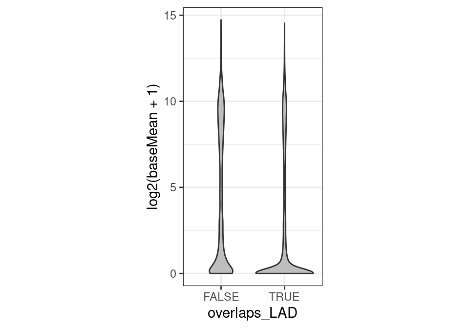

```r
tib_matched %>%
  ggplot(aes(x = overlaps_LAD, y = log2(baseMean+1))) +
  geom_violin(fill = "grey") +
  theme_bw() +
  theme(aspect.ratio = 2)
```

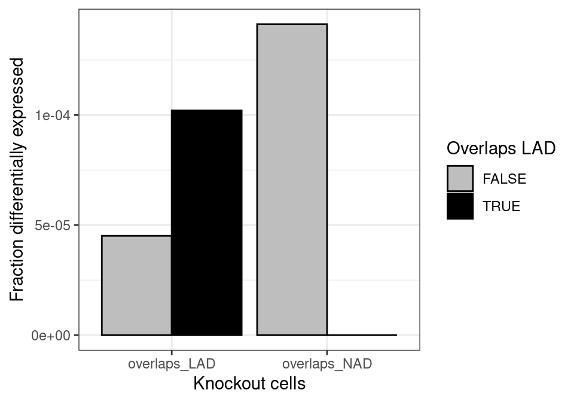

```r
# Repeat enrichment plot
tib_gather <- tib_matched %>%
  dplyr::select(-starts_with("log")) %>%
  gather(key, value, contains("overlaps")) %>%
  mutate(sign = padj < 0.05)

# Group by LAD overlap or significance
tib_diff <- tib_gather %>%
  group_by(key, value) %>%
  dplyr::summarise(fraction = mean(sign),
            total = sum(sign),
            background = length(sign))
#######################################
## Plot results

tib_diff %>%
  ggplot(aes(x = key, y = fraction, fill = value)) +
    geom_bar(stat = "identity", position = "dodge", col = "black") +
    xlab("Knockout cells") +
    ylab("Fraction differentially expressed") +
    scale_fill_manual(values = c("grey", "black"), name = "Overlaps LAD") +
    theme_bw() +
    theme(aspect.ratio = 1)
```

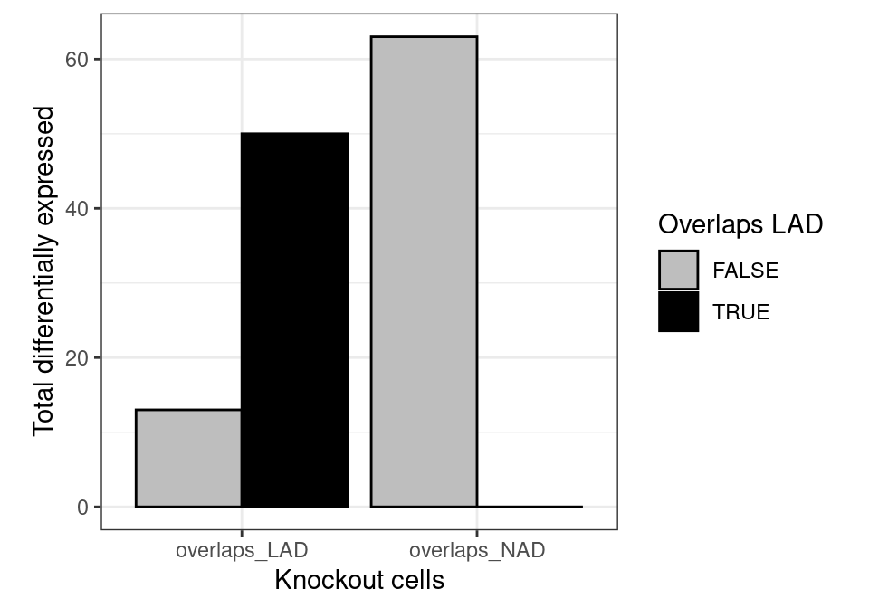

```r
tib_diff %>%
  ggplot(aes(x = key, y = total, fill = value)) +
    geom_bar(stat = "identity", position = "dodge", col = "black") +
    xlab("Knockout cells") +
    ylab("Total differentially expressed") +
    scale_fill_manual(values = c("grey", "black"), name = "Overlaps LAD") +
    theme_bw() +
    theme(aspect.ratio = 1)
```

Not significant.

```r
# This is copied from the same file that I used to determine FPKM values for the
# 4DN cell lines

# Add this as metadata to the DESeq2 object
mcols(rnaseq_dds)$basepairs <- gene_length %>%
  filter(gene_id %in% genes$gene_id) %>%
  pull("exon_length")

# Get FPKM values
rnaseq_fpkm <- as_tibble(fpkm(rnaseq_dds), rownames = "gene_id")

# Get mean FPKM
rnaseq_fpkm_mean <- rnaseq_fpkm %>%
  gather(key, value, -gene_id) %>%
  mutate(key = str_replace_all(key, "-", "_")) %>%
  mutate(condition = metadata$condition[match(key, metadata$sample_name)]) %>%
  group_by(condition, gene_id) %>%
  summarise(mean_expr = mean(value, na.rm = T)) %>%
  ungroup() %>%
  mutate(condition = paste0(condition, "_expr")) %>%
  spread(condition, mean_expr) %>%
  arrange(match(gene_id, genes$gene_id))
```

### Conclusion

Ki67 depletion and the corresponding modest effects on genome organization have no effect on gene expression.

### SessionInfo

```r
# Save data files for other documents
saveRDS(genes, file.path(output_dir, "genes.rds"))
saveRDS(diff_results, file.path(output_dir, "diff_results.rds"))
saveRDS(rnaseq_fpkm_mean, file.path(output_dir, "genes_fpkm.rds"))
saveRDS(metadata, file.path(output_dir, "metadata.rds"))
```